← 使い方一覧に戻る

# ギフトの記録と感謝の管理

## 概要

配信中に受け取ったギフトを記録し、お礼の言い忘れを防ぐ使い方です。継続的に支援してくれるリスナーを把握し、関係性を深めることができます。

セットアップ完了後に行ってください。

## 前提条件

- プラットフォームが登録済みであること
- リスナーが登録済みであること
- 配信が登録済みであること

詳しくは 単一プラットフォームでの配信開始 を参照してください。

## 手順

### 1. ギフトテンプレート作成

1. **よく使うギフトを登録**:
   - 配信詳細画面のギフトセクションで「＋ ギフトを追加」ボタンを押します

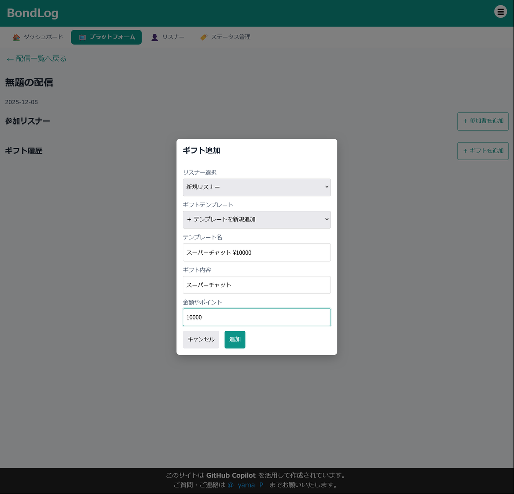

   ギフト追加

   - **リスナー選択** では任意のリスナーを選択します（テンプレート作成時は誰でも構いません）
   - **ギフトテンプレート** から「＋ テンプレートを新規追加」を選択します
   - **テンプレート名** によく使うギフトの名前を入力します
     - 例: 「スーパーチャット ¥500」「ダイヤ 100個」
   - **ギフト内容** に内容を入力します
     - 例: 「スーパーチャット」「ダイヤ」
   - **金額やポイント** に金額やポイント数を入力します
     - 例: 「500」「100」
   - 「追加」ボタンを押します
   - よく使うギフトを複数登録しておくと、入力が効率化されます

**注意**: この操作でギフトテンプレートが登録されると同時に、選択したリスナーのギフト履歴にも追加されます。テンプレート作成のみが目的の場合は、ギフト一覧から追加された行を削除してください。

### 2. ギフト記録

1. **配信中のギフト記録**:
   - 配信詳細画面のギフトセクションで「＋ ギフトを追加」ボタンを押します

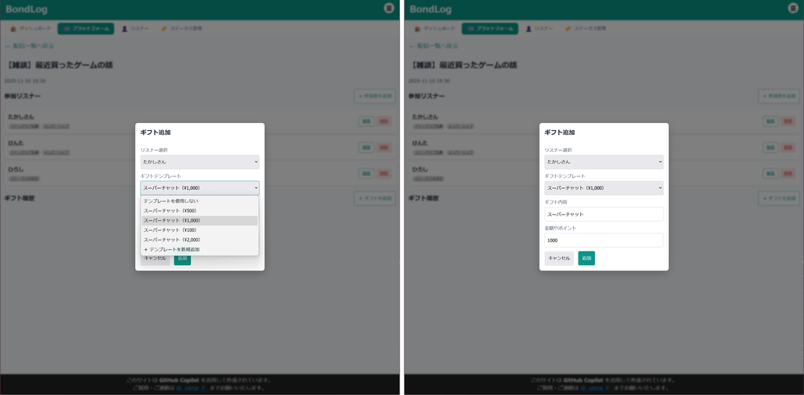

   ギフト追加

   - **リスナー選択** でギフトを送ってくれたリスナーを選択します
     - プラットフォームに関連付けられているリスナーから選択できます
   - **ギフトテンプレート** から該当のギフトを選択します
     - テンプレートを選択すると **ギフト内容** と **金額やポイント** が自動入力されます
   - テンプレートにないギフトの場合は「＋ テンプレートを新規追加」を選択して入力します
   - 「追加」ボタンを押してギフトを記録します
2. **配信後の確認**:
   - 配信詳細画面のギフト一覧で、記録漏れがないか確認します
   - 必要に応じて追加・修正します

### 3. 集計確認

1. **リスナー別の集計**:
   - 「👤 リスナー」タブから該当のリスナーを選択し、リスナー詳細画面を表示します

[figure not shown]

   リスナー詳細

   - ギフト履歴セクションで、このリスナーからのギフト一覧を確認できます
   - 合計金額やポイント数を把握できます
2. **配信別の集計**:
   - 配信詳細画面のギフト一覧で、その配信でのギフト合計を確認できます

### 4. 感謝の確認と継続支援者の把握

1. **配信中のお礼確認**:
   - 配信詳細画面のギフト一覧を確認し、お礼を言えたかチェックします
   - 配信中に読み上げられなかったギフトがあれば、次回配信の冒頭で改めて感謝を伝えます
2. **継続支援者の把握**:
   - 「👤 リスナー」タブから該当のリスナーを選択し、リスナー詳細画面を表示します

[figure not shown]

   リスナー詳細

   - ギフト履歴セクションで、このリスナーの支援状況を確認できます
   - 継続的に支援してくれているリスナーを把握し、配信中の会話で関係を深めます
3. **メモでの記録**:
   - リスナー詳細画面で「編集」ボタンを押してリスナー情報編集モーダルを開きます
   - **メモ** 欄で感謝を伝えた記録やリスナーの好みなどを記録します（最大1,000文字）
     - 例: 「2024/12/01 配信でスパチャのお礼を伝えた。歌枠が好きとのこと」
     - 例: 「いつも応援してくれる。〇〇のゲームが好き」
   - 「保存」ボタンを押して更新します

## ポイント

- テンプレートを活用して入力効率を上げましょう。
- リスナー詳細の集計機能で継続的な支援状況を把握しましょう。
- メモ機能でリスナーの好みや会話内容を記録し、次回の配信に活かしましょう。
- ギフトをくれたリスナーには配信中または次回配信で必ず感謝を伝えましょう。

← 使い方一覧に戻る